# Analiza Danych - Sprawozdanie 2

Test t studenta, przedziały ufności, bootstrap.

Król Monika, Małkowska Alicja, Głuc Kinga

Politechnika Krakowska

# Zadanie 1

Firma A produkuje telefony komórkowe. Na pudełku nowego modelu S firmy A widnieje napis, że bateria wytrzymuje średnio 48 godzin. Nie uwierzyliśmy firmie A i zostawiliśmy na 42 różnych telefonach modelu S włączone wideo tak długo, aż się rozładowały. W pliku *zad2.csv* znajdują się dane zebrane przez nas podczas tego eksperymentu. Uzasadnij, że możesz użyć testu t i użyj testu t, aby zweryfikować, czy firma A nie okłamuje konsumentów.

```r
telefony <- read_csv("zad2.csv")
telefony
```

| number | durability |
| --- | --- |
| 1 | 52.05 |
| 2 | 53.69 |
| 3 | 51.76 |
| 4 | 55.40 |
| 5 | 55.68 |
| 6 | 53.12 |
| 7 | 51.74 |
| 8 | 48.08 |
| 9 | 49.13 |
| 10 | 53.60 |

[output cut: 32 more lines]

Zaczynamy od założeń:

1. Próba ma rozkład normalny Spróbujemy testem Shapiro-Wilka.

Hipotezy:

H0: Dane pochodzą z rozkładu normalnego.

H1: Dane nie pochodzą z rozkładu normalnego.

```r
shapiro.test(telefony$durability)
```

```
##
##  Shapiro-Wilk normality test
##
## data:  telefony$durability
## W = 0.96515, p-value = 0.2249
```

p-value > 0.05, więc możemy uznać, że dane mają rozkład normalny.

2. Próba jest niezależna

Niezależność próby sprawdzimy analizą wykresów scatter plot.

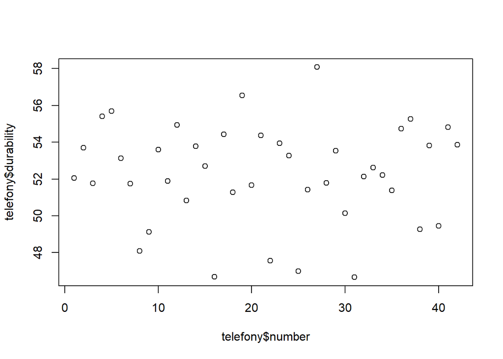

```r
plot(telefony$number, telefony$durability)
```

Nie widać zależności między zmiennymi, więc zakładamy, że próby są niezależne.

Musimy zbadać, czy na podstawie próby przez nas zebranej możemy powiedzieć coś o wszystkich bateriach w nowych modelach S. W tym celu zakładamy hipotezę zerową i formułujemy hipotezę alternatywną. Za hipotezę zerową przyjmujemy stwierdzenie, że prawdziwa średnia wytrzymałość baterii modelu S wynosi 48h, czyli $H_0 : m = 48$. Natomiast hipotezą alternatywną będzie to, że prawdziwa średnia wytrzymałość baterii modelu S nie wynosi 48h, czyli $H_1 : m \neq 48$. Zakładamy, że poziom istotności $\alpha = 0.05$.

W naszym zadaniu nie znamy wariancji, więc musimy użyć oszacowania wariancji z próby. Wówczas zmienna

$$T = \frac{\frac{1}{n}\sum_{i=1}^n X_i -
m}{\frac{s}{\sqrt{n}}} \sim t(n-1)$$

ma rozkład $t$ studenta o $n-1$ stopniach swobody. Rozkład $t$ jest symetryczny względem zera, zatem $P(|Z|>|z|) = P(Z > |z|) + P(Z < - |z|) = 2P(|Z| >|z|)$. Możemy więc porównać naszą wartość $|z|$ z kwantylami $0.025$ i $0.975$ rozkładu $t(n-1)$, aby otrzymać informację o tym, czy nasza obserwacja jest typowa czy nie. Stosując powyższe informacje w naszym zadaniu mamy:

$$T = \frac{\frac{1}{42}\sum_{i=1}^{42}
X_i - 48}{\frac{s}{\sqrt{42}}} \sim t(41)$$

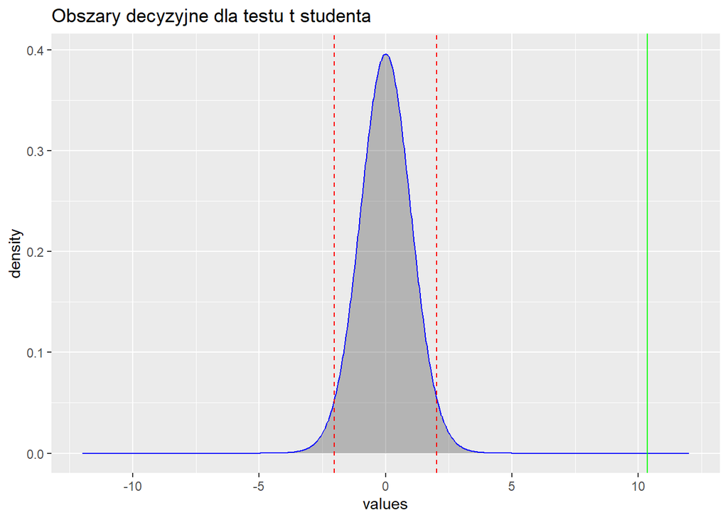

```r
paste("Kwantyl 0.025:", round(qt(0.025, df= (n-1)),2), "Kwantyl 0.975:", round(qt(0.975, df = (n-1)),2), "Nasza wartość z próby:", round(T,2))
```

```
## [1] "Kwantyl 0.025: -2.02 Kwantyl 0.975: 2.02 Nasza wartość z próby: 10.35"
```

Na powyższym wykresie czerwonymi pionowymi liniami zaznaczone są kwantyle 0.025 oraz 0.975. Zielona pionowa linia to wynik t-testu.

Wynik t-testu (10.35) jest znacznie większy od wartości krytycznych dla kwantyli 0.025 (-2.02) i 0.975 (2.02). Na wykresie widać, że wynik t-testu znajduje się poza przedziałem wyznaczonym przez kwantyle 0.025 i 0.975.

Przeprowadzamy test $t$ studenta, aby sprawdzić $p$-value. Jeśli $p$-value wyjdzie większe niż ustalona $\alpha$, to nie odrzucimy hipotezy zerowej i nie będziemy mieli podstaw, by nie uznać, że prawdziwa średnia wytrzymałość baterii nowego telefonu to 48h. Wtedy nie jesteśmy w stanie stwierdzić, czy firma A okłamuje klientów. Jeśli $p$-value wyjdzie mniejsze niż ustalona $\alpha$, to odrzucimy hipotezę zerową i przyjmiemy hipotezę alternatywną. Inaczej mówiąc, uznamy, że prawdziwa średnia wytrzymałość baterii nowego telefonu to nie jest 48h. Wtedy wiemy, że firma A okłamuje klientów.

```r
T
```

```
## [1] 10.34959
```

```r
t.test(telefony$durability, m=48)
```

```
##
##  One Sample t-test
##
## data:  telefony$durability
## t = 10.35, df = 41, p-value = 5.301e-13
## alternative hypothesis: true mean is not equal to 48
## 95 percent confidence interval:
##  51.45556 53.13110
## sample estimates:
## mean of x
##  52.29333
```

Widzimy, że $p$-value równe w przybliżeniu $5.301 \cdot 10^{-13}$ jest dużo mniejsze niż założony poziom istotności $\alpha = 0.05$, więc mamy wystarczające dowody, by odrzucić hipotezę $H_0 : m = 48$ na rzecz hipotezy alternatywnej $H_1 : m \neq 48$. Oznacza to, że firma A okłamuje konsumentów. T-test mówi nam również, że 95% przedział ufności to (51.45556; 53.13110) h, a średnia wartość trwałości baterii telefonu S w analizowanej próbce wynosi 52.29333 h.

# Zadanie 2

Firma B produkuje czekoladę. Po latach zarząd postanowił, że zmienią opakowanie ich czekolady, co na pewno zwiększy sprzedaż. W pliku *zad3t.csv* znajdują się dane ze sprzedaży czekolady z nowym opakowaniem w jednym ze sklepów w jednym z dużych polskich miast oraz dane ze sprzedaży czekolady ze starym opakowaniem w jednym ze sklepów w jednym z dużych polskich miast. Używając testu t studenta sprawdź czy zarząd miał racje i nowe opakowanie zwiększyło sprzedaż.

```r
czekolada <- read_csv("zad3t.csv")
czekolada
```

| pack | sold |
| --- | --- |
| new_pack | 240 |
| old_pack | 220 |
| new_pack | 225 |
| old_pack | 163 |
| new_pack | 172 |
| old_pack | 196 |
| new_pack | 173 |
| old_pack | 166 |
| new_pack | 223 |
| old_pack | 200 |

[output cut: 52 more lines]

Należy zacząć od przygotowania danych do pracy.

```r
czekolada1 <- czekolada %>% pivot_wider(names_from = pack, values_from = sold, values_fn = list) %>% unnest(everything())
print(czekolada1)
```

```
## # A tibble: 31 × 2
##    new_pack old_pack
##       <dbl>    <dbl>
##  1      240      220
##  2      225      163
##  3      172      196
##  4      173      166
##  5      223      200
##  6      200      219
##  7      202      158
##  8      195      206
##  9      196      172
## 10      224      221
## # ℹ 21 more rows
```

Chcemy obliczyć statystykę $t$. Zaczniemy od sprawdzenia, czy dane w kolumnie new_pack i w kolumnie old_pack są równoliczne.

```r
length(czekolada1$new_pack)==length(czekolada1$old_pack)
```

```
## [1] TRUE
```

Zatem dane są równoliczne.

Normalność prób sprawdzimy testem Shapiro-Wilka.

Hipotezy:

H0: Dane pochodzą z rozkładu normalnego.

H1: Dane nie pochodzą z rozkładu normalnego.

```r
shapiro.test(czekolada1$new_pack)
```

```
##
##  Shapiro-Wilk normality test
##
## data:  czekolada1$new_pack
## W = 0.96591, p-value = 0.4142
```

```r
shapiro.test(czekolada1$old_pack)
```

```
##
##  Shapiro-Wilk normality test
##
## data:  czekolada1$old_pack
## W = 0.97916, p-value = 0.789
```

W obu przypadkach p-value > 0.05, więc zakładamy, że obie próby pochodzą z rozkładów normalnych. Sprawdzimy też korelację, by wiedzieć, czy próby są niezależne.

```r
cor(czekolada1$new_pack, czekolada1$old_pack)
```

```
## [1] 0.02767089
```

Korelacja jest bliska 0, więc zakładamy, że zmienne są niezależne.

Chcąc skonstruować statystykę $t$, musimy skorzystać z poprawki Welcha, która umożliwia skonstruowanie statystyki $t$ dla prób, które nie mają jednakowych wariancji lub wielkości.

Po poprawce Welcha, statystyka $t$ przyjmuje postać:
$$t = \frac{(\bar{X_1} -
\bar{X_2}) - (\mu_1-\mu_2)}{s_\Delta},$$
gdzie
$$s_\Delta = \sqrt{\frac{s^2_1}{n_1} +
\frac{s_2^2}{n_2}}.$$

Ustalamy poziom istotności $\alpha=0.05,$ i obliczamy liczbę stopni swobody korzystając ze wzoru
$$df =
\frac{\left( \frac{s_1^2}{n_1} + \frac{s_2^2}{n_2} \right)^2}{
\frac{\left( \frac{s_1^2}{n_1} \right)^2}{n_1 - 1} + \frac{\left(
\frac{s_2^2}{n_2} \right)^2}{n_2 - 1}}.$$
(w kodzie niżej)

Chcemy zweryfikować, czy zmiana opakowania czekolady miała wpływ na zwiększenie sprzedaży. W tym celu zakładamy hipotezę zerową i formułujemy hipotezę alternatywną. Za hipotezę zerową przyjmujemy stwierdzenie, że średnia ilość sprzedaży czekolady z nowym opakowaniem nie różni się od średniej ilości sprzedaży czekolady ze starym opakowaniem. Natomiast hipotezą alternatywną będzie to, że zmiana opakowania ma wpływ na zwiększenie ilości sprzedaży. Przez $x_1$ oznaczymy ilość sprzedaży czekolad w nowym opakowaniu, a przez $x_2$ ilość sprzedaży czekolad w starym opakowaniu. Odpowiednio $\mu_1$ oznacza średnią sprzedaż nowych opakowań, a $\mu_2$ średnią sprzedaż starych opakowań.
$$H_0: \mu_1 = \mu_2, \\
H_1: \mu_1 > \mu_2.$$

Jeśli $p$-value wyjdzie większe niż ustalona $\alpha$, to nie odrzucimy hipotezy zerowej i nie będziemy mieli podstaw, by nie uznać, że zmiana opakowania nie miała wpływu na sprzedaż czekolady. Jeśli $p$-value wyjdzie mniejsze niż ustalona $\alpha$, to odrzucimy hipotezę zerową i przyjmiemy hipotezę alternatywną, czyli uznamy, że zmiana opakowania czekolady miała istotny wpływ na zwiększenie ilości sprzedaży czekolady.

Ponieważ założyliśmy w hipotezie zerowej, że $\mu_1 = \mu_2,$ to $\mu_1 - \mu_2 = 0,$ a zatem wzór na statystykę $t$ przyjmuje postać:

$$t = \frac{(\bar{X_1} -
\bar{X_2})}{s_\Delta}.$$

```r
mean_new <- mean(czekolada1$new_pack)
mean_old <- mean(czekolada1$old_pack)
n_new <- length(czekolada1$new_pack)
n_old <- length(czekolada1$old_pack)
var_new <- var(czekolada1$new_pack)
var_old <- var(czekolada1$old_pack)
alpha=0.05

t <- (mean_new - mean_old)/sqrt(var_new/n_new + var_old/n_old)
df <- (var_new/n_new + var_old/n_old)**2/(((var_new/n_new)**2)/(n_new-1)+((var_old/n_old)**2)/(n_old-1))
pvalue <- 1-pt(abs(t), df)
t
```

```
## [1] 3.769307
```

```r
df
```

```
## [1] 59.99999
```

```r
pvalue
```

```
## [1] 0.0001880395
```

Teraz wykonamy test t-Studenta za pomocą funkcji t.test.

```r
t.test(czekolada1$new_pack, czekolada1$old_pack, alternative="greater")
```

```
##
##  Welch Two Sample t-test
##
## data:  czekolada1$new_pack and czekolada1$old_pack
## t = 3.7693, df = 60, p-value = 0.000188
## alternative hypothesis: true difference in means is greater than 0
## 95 percent confidence interval:
##  12.55439      Inf
## sample estimates:
## mean of x mean of y
##  216.8387  194.2903
```

Wyniki obliczone przez nas zgadzają się z wynikami funkcji t.test.

Z testu t-Studenta możemy odczytać różne wartości, np. średnia sprzedaż nowych opakowań czekolady wyniosła około 216.8387, starych opakowań około 194.2903, liczbę stopni swobody $df=60$, 95% przedział ufności (12.55439, inf) czy statystykę $t=3,7693$. Nas interesuje jednak najbardziej fakt, że wartość $p$-value wyniosła 0.000188, czyli zdecydowanie mniej niż przyjmowany poziom istotności $\alpha=0.05$. Zatem po porównaniu tych dwóch liczb, na mocy testu, odrzucamy hipotezę zerową i przyjmujemy hipotezę alternatywną, a więc stwierdzamy, że zmiana opakowania czekolady miała istotny wpływ na zwiększenie ilości sprzedaży. Zarząd miał rację.

# Wnioski:

## Zadanie 1.

Podsumowując, wyniki otrzymane z testu t-studenta, wykonanego dla zweryfikowania, czy firma A nie okłamuje konsumentów prezentują się następująco:

W tym zadaniu naszym celem było sprawdzenie, czy posiadamy wystarczajaco dowodów, aby przypuszczać, że podawane przez producenta 48h, jako czas pracy baterii, jest nieprawdziwy. Z analizy przeprowadzonej z wykorzystaniem testu t-studenta wynika, że producent okłamuje konsumentów. Uzyskana średnia wytrzymałość baterii to 52.29333 godzin. Przedział ufności 95% z testu t-Studenta jest z kolei równy : (51.45556; 53.13110), a $p$-value z testu t-Studenta wynosi $5.301 \cdot 10^{-13}$.

Interpretacja otrzymanego wyniku pozwala na podejrzenia, że średnia wytrzymałość baterii jest wyższa niż podawane przez producenta 48 godzin.

## Zadanie 2:

Kolejno przypomnijmy również wyniki testu t-studenta dotyczące średniej liczby sprzedaży nowych i starych opakowań.

Średnia sprzedaż nowych opakowań wyniosła 216.8387, z kolei średnia sprzedaż starych opakowań była równa 194.2903. Otrzymany przedział ufności 95% dla różnicy z testu t-Studenta to (12.55439, inf), a $p$-value z testu t-Studenta: 0.000188

Z powyższych danych możemy wywnioskować, że przeprowadzona analiza wskazuje na pozytywny efekt zmiany opakowań na sprzedaż produktu.